# Higher GDP is related to severe covid outcomes

Hojoon Kim

```r
#install.packages(c("skimr", "visdat", "summarytools", "DT"))
#install.packages("devtools")
#devtools::install_github("daattali/ggExtra")
#install.packages("report")
#install.packages("bestNormalize")
```

## Environment set up

```r
#Libaries
library("knitr")
library("tidyverse")
library("DT")
library("ggplot2")
library("ggExtra")
library("patchwork")# for making figure panels
#library("report")
library(bestNormalize)
library(dplyr)

# Setting up the environment before analyzing data.
```

## Project question

**q2** What question will you answer in your project?

I am going to find the which relationship does this data set have with each variable and find the meaningful relationship.

**q3** Motivation: Why is this question interesting and/or important to ask? Ground your explanation in fact. Provide at least one example of how answering this question may be useful in the “real” world.

This question is interesting because COVID-19 has impacted many industries in our fields. Among all, the most issue is about economic effects. It is important because most country’s economy is impacted by COVID in bad ways. It would be helpful to find the relationship between variable and GDP of a country relating to each countries economic situation and HDI(human development index). For example, by finding this relationship, people would be able to estimate or see how each country’s economy situation will change in future.

**q4** Phrase your question in terms of a testable hypothesis. Is there a relationship between total deaths of COVID-19, GDP, and HDI?/ What is the relationship between economic effect of COVID-19 referring each country’s feature and situation./Does the Total cases or total death decreases if the GDP of HDI increases?

## The dataset

**q6** Save your dataset from the R package to your environment.

```r
# Example
# bach_data <- bachelorette
df.covid <- read.csv(file = 'data/transformed_data.csv', fileEncoding="UTF-8-BOM")
```

**q8** Use the glimpse() function take a look at your dataset. How many observations are in your dataset and how many variables?

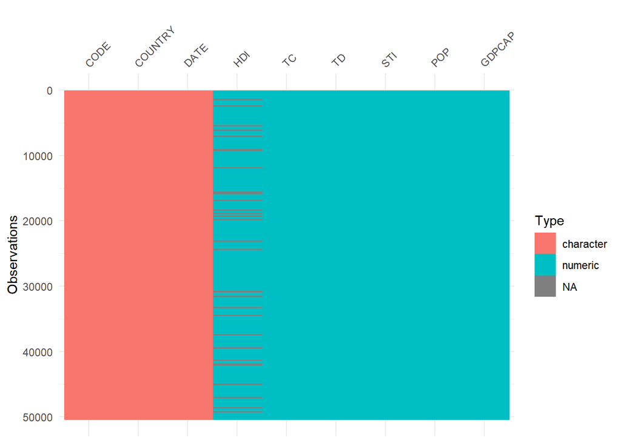

```r
df.covid %>%
  visdat::vis_dat()
```

**q9** Which variables will use to to examine your question? Describe what they are. Include what types of variables they are (e.g., character, integer, etc.) and what their scales of measurement are. country(POP), HDI+GDPCAP, TC, TD: Country is which country it is and POP is population, how many populations are in the country. HDI/GDPCAP is to measure how economic a country is how they live. TC&TD is total cases and total death meaning how many people got COVID-19 and died from COVID-19

## Data challenges

**q10** What will you do to clean and wrangle your dataset to make it appropriate for analysis? For example, will you remove certain columns or rows? Do you need to rename or recode variables? Do you need to create new variables?

I will remove the code variable because I already have the name of the country for the code name variable. It is not useful. For the second I am goijng to remove the date variable becuase I will not use date variable and it will not affect the result of the research.

## Project limitations

**q11** Describe at least two limitations of your data that may make it challenging to draw particular conclusions or interpret your findings (e.g., consider who is in the sample and the design of the study)?

# Part 2

The goals of Part 2 of your project are to:

- Clean and wrangle your data and describe this process.
- Visualize and summarize each of your variables and interpret what you see.

# Data cleaning and wrangling

**q12** In Part 1, you described the necessary data cleaning and wrangling you would need to do to make your data appropriate for analysis (**q10**). Perform this data cleaning below, as well as any additional cleaning/wrangling you need to do. For each data cleaning step, insert a separate chunk of code. For each step, explain why you are doing it in the whitespace below the chunk

```r
df.covid <- df.covid[ ,-1]
```

I erased CODE column in the data df.covid since it is redundant information with variable COUNTRY and I will not use this variable.

normalized total case(TC) and total death(TD) according to population(POP)

```r
df.covid <- df.covid %>% mutate(TCPOP = TC/POP,
                    TDPOP = TD/POP)
```

REMOVED DATA POINTS THAT ARE BELOW ZERO BECAUSE WE EXPECT TO HAVE POSITIVE NUMBERS FOR GROSS DOMESTIC PRODUCT PER CAPITA (GDPCAP), SEXUALLY TRANSMITTED INDEX(STI), HUMAN DEVELOPMENT INDEX (HDI), POPULATION(POP).

```r
df.covid <- df.covid %>% filter(GDPCAP>0, STI>0, HDI>0, POP>0, TC>=0, TD>=0)
```

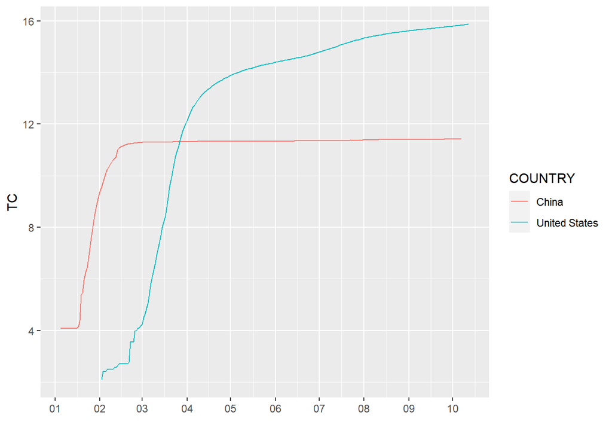

```r
# Most basic bubble plot
df.covid$DATE <- as.Date(df.covid$DATE)
p1 <- ggplot(df.covid %>% filter(COUNTRY == "United States"| COUNTRY == "China"), aes(x=DATE, y=TC, color = COUNTRY)) +
  geom_line() +
  xlab("")
p1 + scale_x_date(date_breaks = "1 month", date_labels = "%m")
```

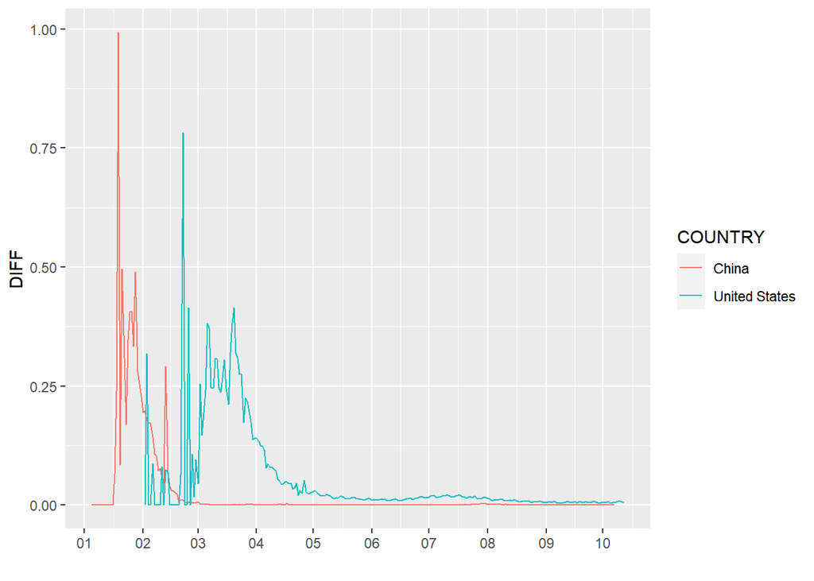

```r
df.covid <- df.covid %>% group_by(COUNTRY) %>% mutate(DIFF = c(0,diff(TC)))
p1 <- ggplot(df.covid %>% filter(COUNTRY == "United States"| COUNTRY == "China"), aes(x=DATE, y=DIFF, color = COUNTRY)) +
  geom_line() +
  xlab("")
p1 + scale_x_date(date_breaks = "1 month", date_labels = "%m")
```

filtered the data only to have last date because total case and total death are accumulative.

```r
df.lastdate <- df.covid %>%
  group_by(COUNTRY) %>%
  slice(which.max(as.Date(DATE)))
df.lastdate$GDPCAP%>%min()
```

```
## [1] 6.494117
```

```r
# df.lastdate %>% mutate(z_HDI = (TC-mean(TC))/sd(TC))
df.lastdate <- df.lastdate %>% mutate(z_HDI = (HDI-mean(df.lastdate $ HDI))/sd(df.lastdate $ HDI), z_TC = (HDI-mean(df.lastdate $ TC))/sd(df.lastdate $ TC), z_TD = (TD-mean(df.lastdate $ TD))/sd(df.lastdate $ TD), z_STI = (STI-mean(df.lastdate $ STI))/sd(df.lastdate $ STI), z_POP = (POP-mean(df.lastdate $ POP))/sd(df.lastdate $ POP), z_GDPCAP = (GDPCAP-mean(df.lastdate $ GDPCAP))/sd(df.lastdate $ GDPCAP))
```

```r
df.lastdate %>% head(10)
```

| COUNTRY | DATE | HDI | TC | TD | STI | POP | GDPCAP | TCPOP | TDPOP | DIFF | z_HDI | z_TC | z_TD | z_STI | z_POP | z_GDPCAP |
| --- | --- | --- | --- | --- | --- | --- | --- | --- | --- | --- | --- | --- | --- | --- | --- | --- |
| Afghanistan | 2020-10-05 | 0.498 | 10.580023 | 7.287561 | 3.218876 | 17.47723 | 7.497754 | 0.6053603 | 0.4169745 | 0.00111905 | -1.3353491 | -3.695650 | 0.49846973 | -1.4445547 | 0.73118707 | -1.4199745 |
| Albania | 2020-10-05 | 0.785 | 9.565634 | 5.981414 | 3.773221 | 14.87254 | 9.376146 | 0.6431744 | 0.4021785 | 0.01049934 | 0.4745854 | -3.582999 | 0.01892356 | -0.2296281 | -0.82124072 | 0.1136488 |
| Algeria | 2020-10-12 | 0.754 | 10.879405 | 7.496097 | 4.329812 | 17.59631 | 9.540639 | 0.6182777 | 0.4260040 | 0.00249028 | 0.2790872 | -3.595167 | 0.57503311 | 0.9902221 | 0.80215765 | 0.2479507 |
| Angola | 2020-10-08 | 0.581 | 8.652598 | 5.327876 | 4.266896 | 17.30796 | 8.668969 | 0.4999202 | 0.3078281 | 0.00000000 | -0.8119186 | -3.663072 | -0.22102019 | 0.8523336 | 0.63029688 | -0.4637298 |
| Argentina | 2020-10-09 | 0.825 | 13.660441 | 10.030561 | 4.476882 | 17.62651 | 9.848710 | 0.7749939 | 0.5690609 | 0.01821106 | 0.7268410 | -3.567299 | 1.50555066 | 1.3125479 | 0.82016025 | 0.4994766 |
| Australia | 2020-10-19 | 0.939 | 10.217933 | 6.806829 | 4.178686 | 17.05418 | 10.706581 | 0.5991452 | 0.3991296 | 0.00025560 | 1.4457697 | -3.522553 | 0.32197126 | 0.6590073 | 0.47904534 | 1.1998904 |
| Austria | 2020-10-15 | 0.908 | 10.991511 | 6.788972 | 3.804660 | 16.01345 | 10.724075 | 0.6863926 | 0.4239545 | 0.02742424 | 1.2502716 | -3.534720 | 0.31541491 | -0.1607230 | -0.14124619 | 1.2141739 |
| Azerbaijan | 2020-10-18 | 0.757 | 10.699124 | 6.434547 | 4.192680 | 16.13192 | 9.670762 | 0.6632270 | 0.3988705 | 0.01198571 | 0.2980064 | -3.593990 | 0.18528918 | 0.6896788 | -0.07063605 | 0.3541901 |
| Bahrain | 2020-10-19 | 0.846 | 11.263207 | 5.703782 | 4.157163 | 14.34707 | 10.675693 | 0.7850528 | 0.3975573 | 0.00425799 | 0.8592753 | -3.559056 | -0.08300777 | 0.6118368 | -1.13442492 | 1.1746722 |
| Bangladesh | 2020-10-07 | 0.608 | 12.825657 | 8.595080 | 4.383151 | 18.91957 | 8.167347 | 0.6779042 | 0.4542957 | 0.00404173 | -0.6416460 | -3.652474 | 0.97851988 | 1.1071225 | 1.59083679 | -0.8732815 |

# Data visualization and summary

**q13** Use `ggplot()` to create histograms (`geom_histogram` or `geom_col`) showing the distributions of each of the variables you are using to test your hypothesis. Only plot one variable per chunk of code. At the end, describe the distribution of each variable in terms of whether it is normal, skewed, bimodal, etc.

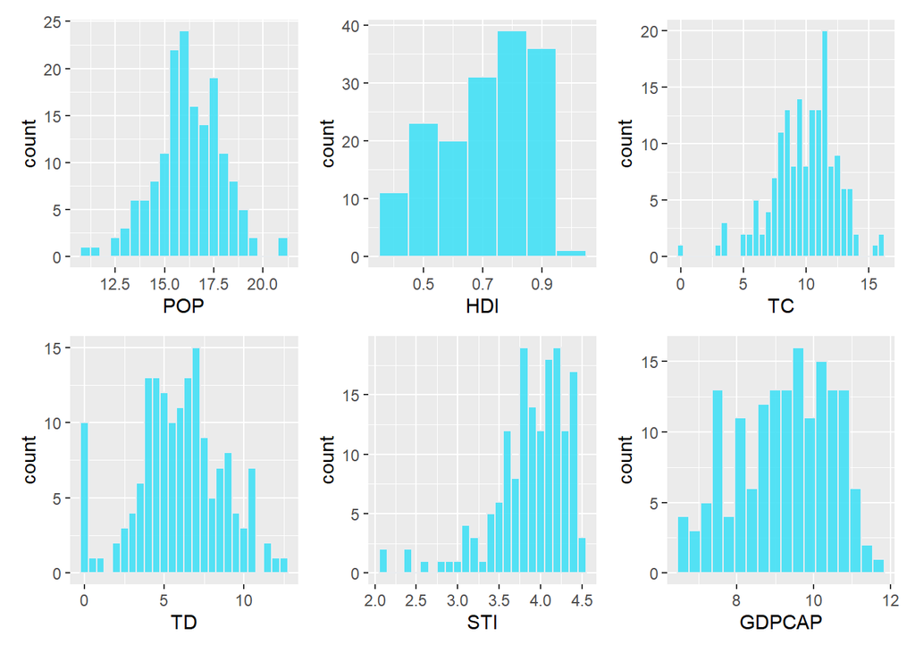

```r
p1 <- df.lastdate %>%
  ggplot( aes(x=POP)) +
    geom_histogram( binwidth=0.5, fill="#42e0f5", color="#e9ecef", alpha=0.9)

p2 <- df.lastdate %>%
  ggplot( aes(x=HDI)) +
    geom_histogram( binwidth=0.1, fill="#42e0f5", color="#e9ecef", alpha=0.9)

p3 <- df.lastdate %>%
  ggplot( aes(x=TC)) +
    geom_histogram( binwidth=0.5, fill="#42e0f5", color="#e9ecef", alpha=0.9)

p4 <- df.lastdate %>%
  ggplot( aes(x=TD)) +
    geom_histogram( binwidth=0.5, fill="#42e0f5", color="#e9ecef", alpha=0.9)

p5 <- df.lastdate %>%
  ggplot( aes(x=STI)) +
    geom_histogram( binwidth=0.1, fill="#42e0f5", color="#e9ecef", alpha=0.9)

p6 <- df.lastdate %>%
  ggplot( aes(x=GDPCAP)) +
    geom_histogram( binwidth=0.3, fill="#42e0f5", color="#e9ecef", alpha=0.9)
    # ggtitle("GDPCAP histogram")
    # theme(
    #   plot.title = element_text(size=20), panel.background = element_blank(), axis.line = element_line(colour = "grey")
    # )

p1 + p2 +p3 + p4 + p5 + p6
```

```r
  plot_layout(ncol=1) &
  theme_classic() &
  theme(
      plot.title = element_text(size=20), panel.background = element_blank(), axis.line = element_line(colour = "grey")
     )
```

```r
# Using bestNormalize library, converted distribution of each variable GDP, HDI, TC, TD
HDI_norm <- bestNormalize(df.lastdate$HDI, allow_lambert_s = TRUE)
HN <- predict(HDI_norm)
GDP_norm <- bestNormalize(df.lastdate$GDPCAP, allow_lambert_s = TRUE)
GN <- predict(GDP_norm)
TC_norm <- bestNormalize(df.lastdate$TCPOP, allow_lambert_s = TRUE)
TC_N <- predict(TC_norm)
TD_norm <- bestNormalize(df.lastdate$TDPOP, allow_lambert_s = TRUE)
TD_N <- predict(TD_norm)

# Added converted distribution of each variable GDP, HDI, TC, TD

df.lastdate$HDI_norm <- HN
df.lastdate$GDP_norm <- GN
df.lastdate$TC_norm <- TC_N
df.lastdate$TD_norm <- TD_N
```

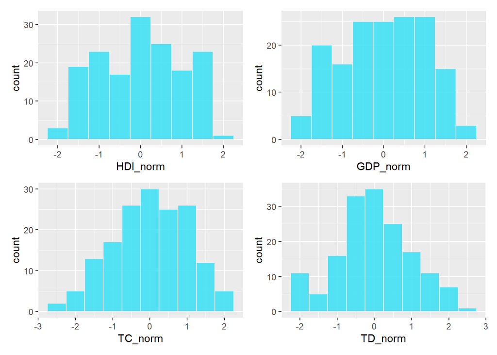

```r
#Plotting histogram of normalized HDI, GDP, TC, TD
p1 <- df.lastdate %>%
  ggplot( aes(x=HDI_norm)) +
    geom_histogram( binwidth=0.5, fill="#42e0f5", color="#e9ecef", alpha=0.9)
p2 <- df.lastdate %>%
  ggplot( aes(x=GDP_norm)) +
    geom_histogram( binwidth=0.5, fill="#42e0f5", color="#e9ecef", alpha=0.9)
p3 <- df.lastdate %>%
  ggplot( aes(x=TC_norm)) +
    geom_histogram( binwidth=0.5, fill="#42e0f5", color="#e9ecef", alpha=0.9)
p4 <- df.lastdate %>%
  ggplot( aes(x=TD_norm)) +
    geom_histogram( binwidth=0.5, fill="#42e0f5", color="#e9ecef", alpha=0.9)

#showing the histogram of normalized variables.
p1 + p2 +p3 + p4
```

```r
  plot_layout(ncol=1) &
  theme_classic() &
  theme(
      plot.title = element_text(size=20), panel.background = element_blank(), axis.line = element_line(colour = "grey")
     )
```

I performed two versions of statistical analysis. The first analysis involved unnormalized variables while second analysis used normalized variables. Two different versions showed similar results therefore I only present results from the unnormailzed version of analysis.

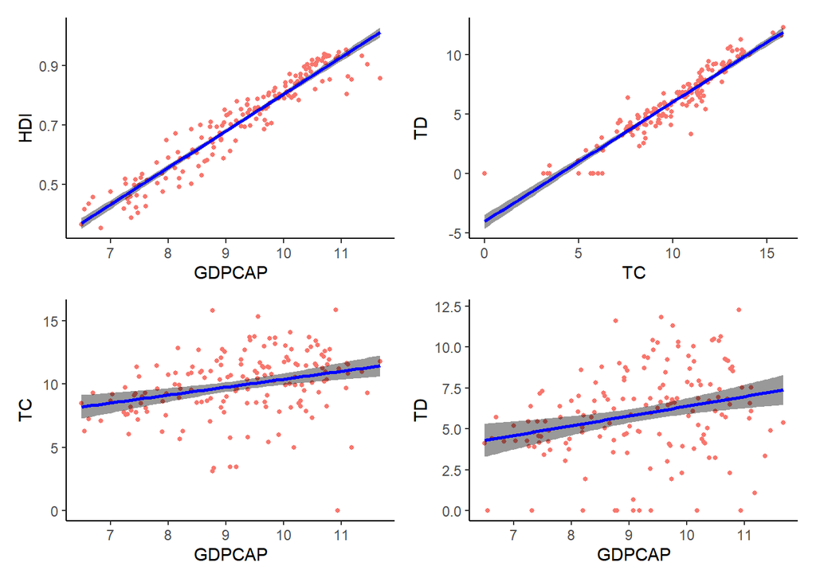

```r
#head(df.covid)

# classic plot :
p1 <- ggplot(df.lastdate, aes(x=GDPCAP, y=HDI, color = "#42e0f5", size=1)) +
      geom_point(alpha = 1, size = 1) +
      geom_smooth(method = "lm", se = T, color = "blue", fill="black", size = 1) +
  theme_classic()+
      theme(legend.position ="none")





# classic plot :
p2 <- ggplot(df.lastdate, aes(x=TC, y=TD, color = "#42e0f5", size=1)) +
      geom_point(alpha = 1, size = 1) +
      geom_smooth(method = "lm", se = T, color = "blue", fill="black", size = 1) +
  theme_classic()+
      theme(legend.position ="none")



p3 <- ggplot(df.lastdate, aes(x=GDPCAP, y=TC, color = "#42e0f5")) +
      geom_point(alpha = 1, size = 1) +
      geom_smooth(method = "lm", se = T, color = "blue", fill="black", size = 1) +
  theme_classic()+
      theme(legend.position = "none")

p4 <- ggplot(df.lastdate, aes(x=GDPCAP, y=TD, color = "#42e0f5")) +
      geom_point(alpha = 1, size = 1) +
      geom_smooth(method = "lm", se = T, color = "blue", fill="black", size = 1) +
  theme_classic()+
      theme(legend.position = "none")


p1 + p2 + p3 +p4
```

```r
  plot_layout(ncol=1) &
  theme(
      plot.title = element_text(size=20), panel.background = element_blank(), axis.line = element_line(colour = "grey")
     )
```

After the normalization procedure of HDI, GDPCAP, TCPOP, TDPOP, each variable’s histogram became left skewed to normally distributed graph. Due to the normalization procedures, values of x-axis and y-axis changed, especially numbers of x-axis became 0 centered.

```r
fit = lm(TDPOP ~ GDPCAP+TCPOP+HDI+POP, data = df.lastdate)
HGa <- aov(fit) %>% summary()

HGa
```

```
##              Df Sum Sq Mean Sq F value Pr(>F)
## GDPCAP        1 0.3447  0.3447  111.61 <2e-16 ***
## TCPOP         1 2.3823  2.3823  771.49 <2e-16 ***
## HDI           1 0.0180  0.0180    5.83 0.0169 *
## POP           1 0.2918  0.2918   94.49 <2e-16 ***
## Residuals   156 0.4817  0.0031
## ---
## Signif. codes:  0 '***' 0.001 '**' 0.01 '*' 0.05 '.' 0.1 ' ' 1
```

```r
fit = lm(TDPOP ~ GDPCAP+HDI+POP, data = df.lastdate)
HGB <- aov(fit) %>% summary()

HGB
```

```
##              Df Sum Sq Mean Sq F value   Pr(>F)
## GDPCAP        1 0.3447  0.3447   26.59 7.47e-07 ***
## HDI           1 0.0933  0.0933    7.20  0.00807 **
## POP           1 1.0457  1.0457   80.69 7.83e-16 ***
## Residuals   157 2.0347  0.0130
## ---
## Signif. codes:  0 '***' 0.001 '**' 0.01 '*' 0.05 '.' 0.1 ' ' 1
```

```r
fit = lm(TCPOP ~ GDPCAP+HDI+POP, data = df.lastdate)
HGC <- aov(fit) %>% summary()

fit
```

```
##
## Call:
## lm(formula = TCPOP ~ GDPCAP + HDI + POP, data = df.lastdate)
##
## Coefficients:
## (Intercept)       GDPCAP          HDI          POP
##    -0.13525      0.01985      0.23022      0.02431
```

```r
HGC
```

```
##              Df Sum Sq Mean Sq F value   Pr(>F)
## GDPCAP        1 0.4637  0.4637  36.217 1.20e-08 ***
## HDI           1 0.0286  0.0286   2.234    0.137
## POP           1 0.2604  0.2604  20.339 1.26e-05 ***
## Residuals   157 2.0099  0.0128
## ---
## Signif. codes:  0 '***' 0.001 '**' 0.01 '*' 0.05 '.' 0.1 ' ' 1
```

```r
fit = lm(TD_norm ~ GDP_norm+TC_norm+HDI_norm+POP, data = df.lastdate)
HGa_n <- aov(fit) %>% summary()

HGa_n

fit = lm(TD_norm ~ GDP_norm+HDI_norm+POP, data = df.lastdate)
HGB_n <- aov(fit) %>% summary()

HGB_n

fit = lm(TC_norm ~ GDP_norm+HDI_norm+POP, data = df.lastdate)
HGC_n <- aov(fit) %>% summary()

fit

HGC_n
```

[output not shown]

```r
c1 <- cor.test(df.lastdate$GDPCAP,df.lastdate$HDI)

c2 <- cor.test(df.lastdate$TC, df.lastdate$TD)

c3 <- cor.test(df.lastdate$GDPCAP,df.lastdate$TCPOP)
```

All 3 have significant relationship between each variables and all of it has positive slope which means that it has positive relationship. Pearson’s correlation test revealed that GDPCAP and HDI has a strong positive relationship p = 0 r(159) = 0.956 and similar positive relationship was found for TC and TD p = 0 r(159) = 0.939 and lastly TCPOP and GDPCAP also showed positive relationship p = 0 r(159) = 0.41 As expected GDPCAP and HDI had strong positive relationship because HDI is measurement for Human development which is known to be a measure that is indicative of a country’s wealth. More total cases leads to more total death due to covid as seen in above graph.

Beyond that I thought that better infrastructure would prevent people from dying even if they are infected by their covid but the result did not come out as I expected. Maybe this is due to the fact that there is no active way of treating covid yet.

```r
fit = lm(HDI ~ 1 + GDPCAP, data = df.lastdate)
HGsum <- aov(fit) %>% summary()

fit = lm(TC ~ 1 + TD, data = df.lastdate)

CDsum <- aov(fit)%>%summary()

fit = lm(TCPOP ~ 1 + GDPCAP, data = df.lastdate)

CGsum <- aov(fit)%>%summary()

HGsum
```

```
##              Df Sum Sq Mean Sq F value Pr(>F)
## GDPCAP        1  3.680   3.680    1705 <2e-16 ***
## Residuals   159  0.343   0.002
## ---
## Signif. codes:  0 '***' 0.001 '**' 0.01 '*' 0.05 '.' 0.1 ' ' 1
```

```r
CDsum
```

```
##              Df Sum Sq Mean Sq F value Pr(>F)
## TD            1  916.0   916.0    1189 <2e-16 ***
## Residuals   159  122.5     0.8
## ---
## Signif. codes:  0 '***' 0.001 '**' 0.01 '*' 0.05 '.' 0.1 ' ' 1
```

```r
CGsum
```

```
##              Df Sum Sq Mean Sq F value  Pr(>F)
## GDPCAP        1 0.4637  0.4637   32.07 6.8e-08 ***
## Residuals   159 2.2989  0.0145
## ---
## Signif. codes:  0 '***' 0.001 '**' 0.01 '*' 0.05 '.' 0.1 ' ' 1
```

Individual predictors relationship were analyzed using linear models. HDI and GDP(F(1, 159) = 1705, p < 0.001) showed significant linear relationship, which confirms previous correlation result. TC and TD(F(1, 159) = 1189, p < 0.001) showed significant linear relationship as expected and it matches with the previous result.

```r
fit = lm(HDI_norm ~ 1 + GDP_norm, data = df.lastdate)
HG_nsum <- aov(fit) %>% summary()

fit = lm(TC_norm ~ 1 + TD_norm, data = df.lastdate)

CD_nsum <- aov(fit)%>%summary()

fit = lm(TC_norm ~ 1 + GDP_norm, data = df.lastdate)

CG_nsum <- aov(fit)%>%summary()

HG_nsum
```

```
##              Df Sum Sq Mean Sq F value Pr(>F)
## GDP_norm      1    145  145.00    1537 <2e-16 ***
## Residuals   159     15    0.09
## ---
## Signif. codes:  0 '***' 0.001 '**' 0.01 '*' 0.05 '.' 0.1 ' ' 1
```

```r
CD_nsum
```

```
##              Df Sum Sq Mean Sq F value Pr(>F)
## TD_norm       1 124.26  124.26   552.7 <2e-16 ***
## Residuals   159  35.74    0.22
## ---
## Signif. codes:  0 '***' 0.001 '**' 0.01 '*' 0.05 '.' 0.1 ' ' 1
```

```r
CG_nsum
```

```
##              Df Sum Sq Mean Sq F value   Pr(>F)
## GDP_norm      1  36.77   36.77   47.44 1.25e-10 ***
## Residuals   159 123.23    0.78
## ---
## Signif. codes:  0 '***' 0.001 '**' 0.01 '*' 0.05 '.' 0.1 ' ' 1
```

```r
test1<-cor.test(df.covid$TC,df.covid$TD)
test2<-cor.test(df.covid$GDPCAP,df.covid$HDI)
```

```r
test1
```

```
##
##  Pearson's product-moment correlation
##
## data:  df.covid$TC and df.covid$TD
## t = 452.5, df = 36633, p-value < 2.2e-16
## alternative hypothesis: true correlation is not equal to 0
## 95 percent confidence interval:
##  0.9194315 0.9225398
## sample estimates:
##       cor
## 0.9210003
```

**q14** Summarize each of the numeric variables you will use to test your hypothesis with the central tendency and standard deviation. For categorical/character variables, summarize with the frequency in each category

**q15** What is the null hypothesis?

Total cases of covid has no relationship between Gross Domestic Product, Human Develop Index of the country. This means that number of covid cases and GDP, HDI are independent of each other.

**q16** Test your hypothesis using the appropriate statistical tests. Points to consider: Are your variables continuous or categorical? If your variables are continuous, are they normally distributed? If one or more of your variables is categorical, how many categories are there?

Total Cases, GDP, and HDI are continuous variables. By plotting histogram for each variable, they are not normally distributed, all of them is left skewed. HDI has most left skewed result, followed by GDP and Total Cases. Although GDP and Total Cases show a slight left skewness, overall they are normally distributed. To correct the left skewness, we used bestNormalize function to convert our orignal data to normalized data.

# Effect size

**q18** Estimate how large the effect(s) are. Regardless of whether your hypothesis test was “significant”, quantify the size of the effect using measure of effect sizes (e.g., odds ratio or standardized residual for chi-square test; strength of the correlation coefficient; standardized mean difference [cohen’s d] for comparing means; standardized beta and/or R-squared for linear regression), confidence intervals, and/or Bayes factors. Interpret the the effect size in writing.

*Example*: *We computed the odds-ratio for the probability of Black individuals being searched by the police versus the probability of White individuals being searched by the police. Black individuals were 2.59 times more likely to be searched by the police than were White individuals.*